# distribution function in R

### Normal Distribution

generate normal distribution dataset.

`r`r normal_dataset <- rnorm(200, mean = 24, sd=3)

so this dataset have N=200, mean =24 and sd=3.

`r`r hist(normal_dataset)

[figure not shown]

$$\mu = mean$$
$$\sigma= standard.deviation$$

$$f(x|\mu,\sigma) = \frac{1}{\sigma \sqrt{2 \pi}}~\exp \left( - \frac{(x - \mu )^2}
{2 \sigma^2} \right)$$

`r`r #prob <- (1/(s * sqrt(2*pi)))* exp(-((x-mu)^2)/(2*s^2)) p_normal_dis <- function(x, mu=0, s=1) { p <- (1/(s* sqrt(2*pi)))* exp(-((x-mu)^2)/(2*s^2)) p }

`r`r prob <- p_normal_dis(normal_dataset,24,3)

`r`r y_dnor <- dnorm(normal_dataset, mean = 24, sd=3)

`r`r plot(normal_dataset, prob, col=‘blue’)

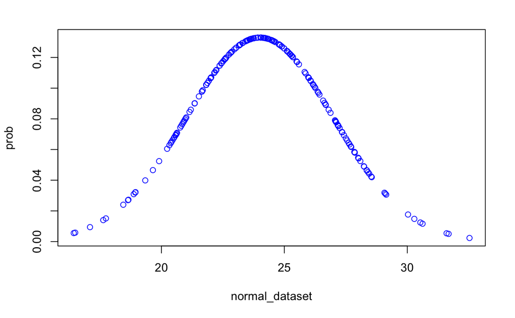

`r`r plot(normal_dataset, y_dnor, col=‘red’)

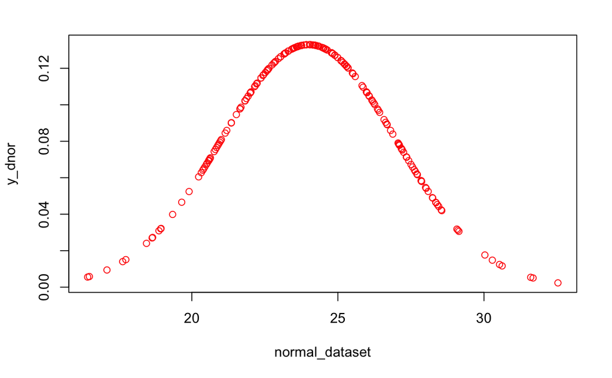

`r`r pnorm(30, mean = 24, sd=3, lower.tail = T)

```
[1] 0.9772499
```

`r`r qnorm(.9772499, 24, 3)

```
[1] 30
```

$$Z= \frac{x-\mu}{\sigma}$$

`r`r z_score <- function(x) { mu <- mean(x) sd <- sd(x) z <- (x-mu)/sd z }

`r`r z_data <- z_score(normal_dataset)

`r`r hist(z_data)

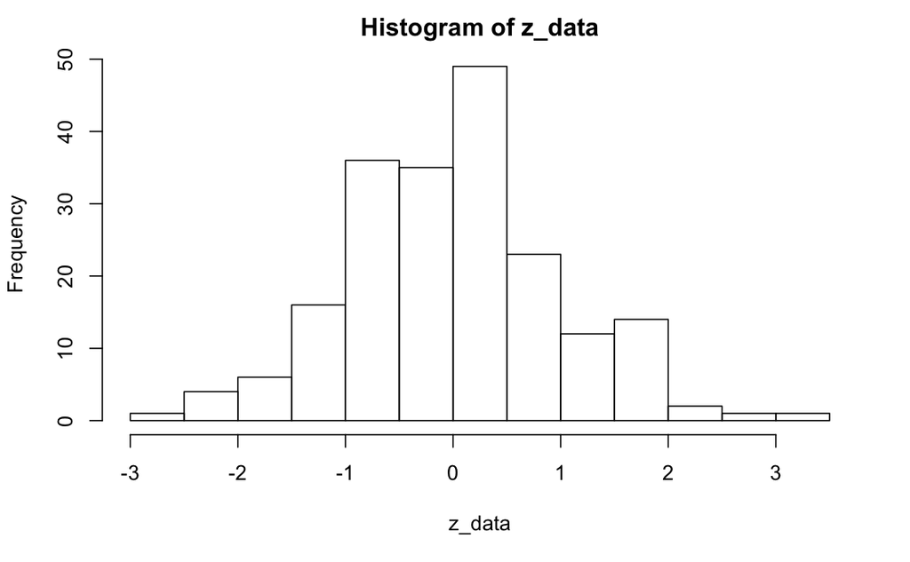

`r`r plot(z_data,prob)

[figure not shown]

`r`r

dnorm(23, mean = 24, sd=3)

```
[1] 0.1257944
```

`r`r qnorm(.3, mean = 24, sd=3)

```
[1] 22.4268
```

`r`r pnorm(23, mean = 24, sd=3)

```
[1] 0.3694413
```

`r`r qnorm(.3694413, mean = 24, sd=3)

```
[1] 23
```

### binomial distribution

n trial,  
k successes, **(with replacement)**  
fixed probability

$$PMF : {{n}\choose{k}} \cdot p^k(1-p)^{n-k}$$

`r`r num_flips <- 10 coin <- c(‘head’, ‘tail’) # head 1, tail 0, or success 1, failure 0 flips <- list(sample(coin, size = num_flips, replace = TRUE)) flips

```
[[1]]
 [1] \head\ \tail\ \head\ \tail\ \tail\ \tail\ \head\ \tail\ \head\ \head\
```

`r`r binom_dataset <- rbinom(2000, 10, 0.5)

`r`r p_dbinom <- dbinom(binom_dataset, 10, .5)

`r`r plot(binom_dataset, p_dbinom)

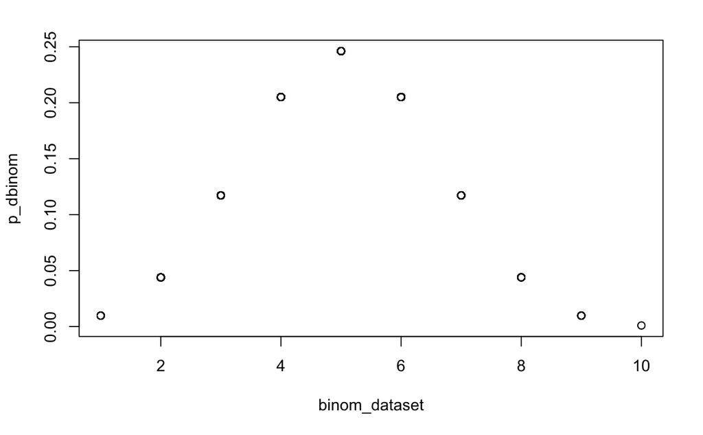

[link](https://www.tutorialspoint.com/r/r_binomial_distribution.htm)

```r
# Create a sample of 50 numbers which are incremented by 1.
x <- seq(0,50,by = 1)

# Create the binomial distribution.
y <- dbinom(x,50,0.5)
```

pbinom()

This function gives the cumulative probability of an event. It is a single value representing the probability.

```r
# Probability of getting 26 or less heads from a 51 tosses of a coin.
x <- pbinom(26,51,0.5)

x
```

qbinom()

This function takes the probability value and gives a number whose cumulative value matches the probability value.

```r
# How many heads will have a probability of 0.25 will come out when a coin
# is tossed 51 times.
x <- qbinom(0.25,51,1/2)
x
```

This function generates required number of random values of given probability from a given sample.

```r
# Find 8 random values from a sample of 150 with probability of 0.4.
x <- rbinom(8,150,.4)
x
```

### beta distribution

[link for parameter calculation](https://stats.stackexchange.com/questions/12232/calculating-the-parameters-of-a-beta-distribution-using-the-mean-and-variance)

```r
#beta distribution

alpha <- 81
beta <- 219

data_beta <- rbeta(100, alpha, beta)
plot(data_beta, dbeta(data_beta, alpha, beta), col='red')


#new 300 n added. success 100, miss 200
plot(data_beta, dbeta(data_beta, 181, 419), col='green')
```

```r
estBetaParams <- function(mu, var) {
  alpha <- ((1 - mu) / var - 1 / mu) * mu ^ 2
  beta <- alpha * (1 / mu - 1)
  return(params = list(alpha = alpha, beta = beta))
}
```